# QTL Mapping of Lentil Defence Response to *Ascochyta lentis*

Genome-by-Sequencing (ddRAD) Data Analysis Pipeline

Ido Bar

10 October 2017

## Study Description

### Experimental Design

Two distinct lentil (*Lens culinaris*) genotypes, resistant and susceptible to Ascochyta blight disease (**ILL7537** and **ILL6002**, respectively) were crossed and the F1 was recursively self-pollinated to create an F5 population. The population was sown and challenged with an inoculation of *Ascochyta lentis* (isolate AL4) and quantitatively phenotyped by four stem and leaf damage traits over the course of 4 weeks, at 7, 14, 21 and 28 days post inoculation (dpi).

### Genotyping

Both parent genotypes (x3 replicates each) and their F5 (n=144) progeny population, as well as represantatives of “Boomer” cultivar, were sent for genotyping-by-sequencing (GBS; AGRF, Adelaide). The AGRF uses ddRAD-based library preparation protocol, based on Peterson *et al.* (2012). The DNA was digested using a combination of restriction enzymes (*EcoRI* and *MseI*) and only tags with both RE sites (one in each end) were selected for library preparation and sequenced on 2 lanes of an Illumina HiSeq2500 sequencing platform, producing 100 bp single-end reads (see per sample sequencing details in Table 1).  
In average, 4.16e+06 reads were sequenced for each F5 sample, covering 219,648 tags (loci), at a depth of x16.0; whereas for the parent lines, it was 8.86e+06 reads, covering 282,954 tags at a depth of x28.6.  
Basic bioinformatics analysis was performed by AGRF, mainly running the [Stacks](http://catchenlab.life.illinois.edu/stacks/) v1.47 pipeline (Catchen *et al.* 2011; Catchen *et al.* 2013) to build a catalogue of consensus tag sequences to call variants from each sample.

```r
DT::datatable(GBS_read_data, caption = tbls(name="GBS_read_table"), rownames = FALSE)
```

| N | Sample | Barcode | Tags in Catalogue | Tags Total | Average Tag Depth | SD of Depth | Reads | Gen |
| --- | --- | --- | --- | --- | --- | --- | --- | --- |
| 1 | C1_004-I6 | AACT | 195814 | 201379 | 12.2 | 131.4 | 2727990 | F5 |
| 2 | C1_005-I6 | CTGT | 90371 | 93197 | 7.2 | 48.9 | 826004 | F5 |
| 3 | C1_008-I6 | CGTAC | 157691 | 162517 | 10 | 94.3 | 1850506 | F5 |
| 4 | C1_009-I6 | TGAACC | 182458 | 188132 | 11.9 | 133.3 | 2495312 | F5 |
| 5 | C1_010-I6 | GCGATGC | 177803 | 183610 | 11.3 | 118.4 | 2326055 | F5 |
| 6 | C1_013-I6 | CGGATGGC | 179279 | 185168 | 10.6 | 99.7 | 2210622 | F5 |
| 7 | C1_014-I12 | AACT | 258049 | 267188 | 19.8 | 262.7 | 5694668 | F5 |
| 8 | C1_015-I12 | CTGT | 207644 | 215083 | 13.1 | 137.6 | 3109857 | F5 |
| 9 | C1_016-I12 | CGTAC | 186824 | 193505 | 13.2 | 145.4 | 2804072 | F5 |
| 10 | C1_017-I12 | TGAACC | 233379 | 242302 | 16.6 | 210.9 | 4372271 | F5 |

[output cut: 142 more lines]

### Analysis Approach

1. Assess Stacks2 *de novo* parameters for maximum coverage and minimum error rates
2. Combine each parent read files to one file (to increase coverage for them)
3. Call variants using Stacks2 *de novo* pipeline using optimal parameters
4. Map catalog back to the lentil genome (v1.2; UoS)
5. Integrate aligned tags into the catalog and match chromosomal position to each loci
6. Filter output files (remove samples and loci with too much missing information)
7. Perform linkage mapping and order markers inside each chromosome/linkage group
8. QTL analysis and visualisation
9. Annotation of SNPs under the QTLs

## Methodologies

### Stacks pipelines

AGRF provided the results of the Stacks *de novo* pipeline, run as a general population of samples. Alternatively, run Stacks2 `ref_map.pl` or `denovo_map.pl` pipelines.  
Other alternatives to Stacks are Heap or TASSEL (Glaubitz *et al.* 2014)

### Stacks2 pipeline

A new version of Stacks (v2.0b) is now available and the recommended approach, even when a reference genome is available, is to incorporate the reference genome alignment information by building loci *de novo* and subsequently integrating the alignments of the consensus sequences into their *de novo* dataset (Paris *et al.* 2017).

#### Assess errors in read files

```bash
# Combine read files from parents
cd ~/data/Lentil_GBS/AGRF_CAGRF14978_CB2YGANXX_gbs/fastq
ls -1 ILL7537_00?_RF* | xargs cat > ILL7537_RF.fq.gz
ls -1 ILL6002_00?_RF* | xargs cat > ILL6002_RF.fq.gz
# backup original files
my_rename -v 's/gz/gz.bak/' ILL*_00?_RF*
# Prepare filter_kmer commands - process one file at a time
JOB_NAME="filter_kmer"
mkdir ~/data/Lentil_GBS/AGRF_CAGRF14978_CB2YGANXX_gbs/fastq/kmer_filtered
cd !$
DATE=`date +%d_%m_%Y`
find ~/data/Lentil_GBS/AGRF_CAGRF14978_CB2YGANXX_gbs/fastq -maxdepth 1 -name "*.fq.gz" | gawk '{n=split($1,a,"/"); name=gensub(/_[ACGT]+\.fq\.gz/, "", "1", a[n]); printf "pigz -cd %s > %s.fq \n", $1, name}' > ${JOB_NAME}_${DATE}.cmds

# Prepare PBS script
echo '#!/bin/bash
#PBS -V
#PBS -l select=1:ncpus=1:mem=8GB,walltime=1:00:00
#PBS -m be
#PBS -M i.bar@griffith.edu.au

cd $PBS_O_WORKDIR
gawk -v ARRAY_IND=$PBS_ARRAY_INDEX "NR==ARRAY_IND" $CMDS_FILE | bash' > ${JOB_NAME}_${DATE}.pbs

# submit the jobs to the scheduler
JOBS_NUM=`wc -l ${JOB_NAME}_${DATE}.cmds | gawk '{print $1}'`
qsub -J1-${JOBS_NUM} -N $JOB_NAME -v CMDS_FILE=${JOB_NAME}_${DATE}.cmds ${JOB_NAME}_${DATE}.pbs
# Job Array ID 4988299[]
# to process all files at once - gunzip them to a folder and run on the entire folder
$HOME/etc/tools/SNP/stacks-2.0/bin/kmer_filter -p ~/data/Lentil_GBS/AGRF_CAGRF14978_CB2YGANXX_gbs/fastq/kmer_filtered -o ~/data/Lentil_GBS/AGRF_CAGRF14978_CB2YGANXX_gbs/fastq/kmer_filtered --rare --abundant --write_k_freq all_files.kfreq
```

#### Parameter and error estimation using de novo pipeline

A subset of samples was selected, including the parent replicates (non-combined) and 20 other randomally selected genotypes. A *de novo* pipeline was run several times with the selected samples, varying just one parameter with each parse of the program. For the primary analysis, we varied the `ustacks` **m** parameter from 3 to 7, the `ustacks` **M** parameter from 1 to 8 and the `cstacks` **n** parameter as $n=M\pm\ 1$, while keeping all other parameters consistent (Stacks2 defaults are m3, M2 and n0), as described by (Mastretta‐Yanes *et al.* 2015; Paris *et al.* 2017; Rochette and Catchen 2017).

```bash
# Sample selection
JOB_NAME="denovo_param_est"
DATE=`date +%d_%m_%Y`
cd $HOME/data/Lentil_GBS/AGRF_CAGRF14978_CB2YGANXX_gbs/fastq
mkdir ${JOB_NAME}_$DATE && cd ${JOB_NAME}_$DATE
# Link parent files into the folder
ls -1 ../*.fq.gz* | grep -vE "NegControl|/C|_RF.fq.gz" | xargs -I{} ln -s {} ./
# link 20 random sample files
ls -1 ../*.fq.gz* | grep -vE "NegControl|/ILL" | sort -R | head -n 20 | xargs -I{} ln -s {} ./
# rename filenames
my_rename -v 's/-I\d+_[ACGT]+.fq.gz[.bak]*/.fq.gz/' *
# Create popmap
ls -1 *.fq.gz | gawk '{sample=gensub(".fq.gz", "", "1", $1); printf "%s\tRIL5\n", sample}' > ${JOB_NAME}_popmap.txt

# Create all the denovo jobs
NCPUS=6
# Add default parameters
echo "mkdir -p ./stacks_M2m3n0/populations.r80; \$HOME/etc/tools/SNP/stacks-2.0/bin/denovo_map.pl -T $NCPUS -m 3 -M 2 -n 0 -o ./stacks_M2m3n0/ --samples ./ --popmap ./denovo_param_est_popmap.txt -X \"populations: --vcf --genepop\" &&
\$HOME/etc/tools/SNP/stacks-2.0/bin/populations -t $NCPUS -P ./stacks_M2m3n0/ -O ./stacks_M2m3n0/populations.r80 -r 0.80 --vcf --genepop" > ${JOB_NAME}_$DATE.cmds
# Then the rest of the combinations
echo '#!/bin/bash
for m in {3..7}; do
  for M in {1..8}; do
    for (( n = $(( M-1 )); n <= $(( M+1 )); n++ )); do
      echo "mkdir -p ./stacks_M${M}m${m}n${n}/populations.r80; \$HOME/etc/tools/SNP/stacks-2.0/bin/denovo_map.pl -T $NCPUS -M $M -m $m -n $n -o ./stacks_M${M}m${m}n${n}/ --samples ./ --popmap ./denovo_param_est_popmap.txt -X \"populations: --vcf --genepop\" && \$HOME/etc/tools/SNP/stacks-2.0/bin/populations -t $NCPUS -P ./stacks_M${M}m${m}n${n}/ -O ./stacks_M${M}m${m}n${n}/populations.r80 -r 0.80 --vcf --genepop"
    done
  done
done' | bash >> ${JOB_NAME}_$DATE.cmds

# mkdir ./stacks_M${M}m${m}n${n}/populations.r80 && $HOME/etc/tools/SNP/stacks-2.0/bin/populations -t 12 -P ./stacks_M${M}m${m}n${n}/ -O ./stacks_M${M}m${m}n${n}/populations.r80 -r 0.80 --vcf --genepop
# Prepare PBS script
echo '#!/bin/bash
#PBS -V
#PBS -l select=1:ncpus=12:mem=16GB,walltime=100:00:00
#PBS -m be
#PBS -M i.bar@griffith.edu.au

cd $PBS_O_WORKDIR
gawk -v ARRAY_IND=$PBS_ARRAY_INDEX "NR==ARRAY_IND" $CMDS_FILE | bash' > ${JOB_NAME}_${DATE}.pbs

# submit the jobs to the scheduler
JOBS_NUM=`wc -l ${JOB_NAME}_${DATE}.cmds | gawk '{print $1}'`
qsub -J1-${JOBS_NUM} -v CMDS_FILE=${JOB_NAME}_${DATE}.cmds -N ${JOB_NAME:0:11} ${JOB_NAME}_${DATE}.pbs
# Job ID 4989117[] also run on Awoonga - 75828[].awongmgmr1

# extract the information from the log file of each parameter combination Stacks run
find . -wholename "*populations.r80/populations.log" | xargs grep -Po "\d+\/\d+\/\d+" | gawk -F[/] 'BEGIN{printf "M_param\tm_param\tn_param\tAssembled_loci_r80\tPolymorphic_loci_r80\n"}{match($0, /stacks_M([0-9])m([0-9])n([0-9])/, params); match($0, /([0-9]+)\/([0-9]+)\/([0-9]+)/, vars); printf "%s\t%s\t%s\t%s\t%s\n",params[1],params[2], params[3], vars[1], vars[2]}' > denovo_param_est_r80_populations.log
# extract the coverage information from the log file of each parameter combination Stacks run
find . -name "denovo_map.log" | xargs grep -P "per-sample coverage" | gawk 'BEGIN{printf "M_param\tm_param\tn_param\tmean_coverage\tstdev_coverage\tmin_coverage\tmax_coverage\n"}{match($0, /stacks_M([0-9])m([0-9])n([0-9])/, params); match($0, /mean=([0-9\.]+)x.+=([0-9\.]+)x.+=([0-9\.]+)x.+=([0-9\.]+)x/, cov_stats); printf "%s\t%s\t%s\t%s\t%s\t%s\t%s\n", params[1],params[2], params[3], cov_stats[1], cov_stats[2],cov_stats[3],cov_stats[4]}' > denovo_param_est_coverage.log
# Get error rates
Rscript process_params_vcf_files.R

# Then copy denovo_param_est_r80_populations.log, denovo_param_est_coverage.log, stacks_param_error_rates_*.tsv to local computer (under GBS_analysis/data folder)
```

The resulting `.log` files were parsed to retrieve the following statistics:  
1. The parameters **m** and **M** and **N**  
2. The number of assembled loci (from `populations.log` files)  
3. The number of polymorphic loci shared across most samples (the r80 loci)  
4. The distribution of the number of SNPs per locus (from `populations.snps.vcf` files)  
5. The coverage per sample (from `denovo_map.log` files)

Replicate samples were used to estimate the rates of three types of errors:  
1. Locus error rate, corresponding to missing data at the locus level and measured as **the number of loci present in only one of the samples of a replicate pair**, divided by the total number of loci found.  
2. Allele error rate, calculated as the **number of allele mismatches between replicate pairs, divided by the number of loci being compared** (all the SNPs within a tag).  
3. SNP error rate, measured as the proportion of SNP mismatches between replicate pairs.  
(See explanation in Figure 1)

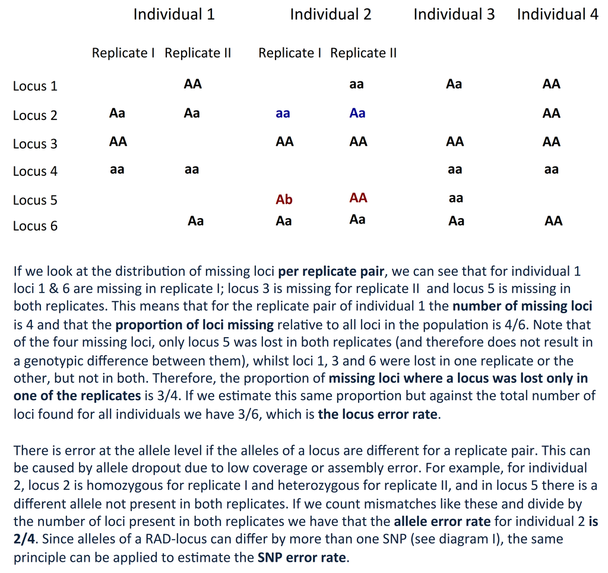

Figure 1: Error types between replicates in RAD-Seq.

```r
# read log files with loci stats
param_stats <- read_tsv("data/denovo_param_est_r80_populations.log")

#### coverage stats ####
cov_stats <- read_tsv("data/denovo_param_est_coverage.log")#

#### Error estimation between replicates  ####
# Find most recent file
error_rates_files <- file.info(list.files(path = "./data",
                                          pattern="stacks_param_error_rates.*.tsv", full.names = TRUE)) %>%
  rownames_to_column(var = "filename")  %>% mutate_at(.vars = vars(ends_with("time")), as.POSIXct) %>%
  arrange(desc(mtime))
recent_file <- error_rates_files$filename[1]

error_rates_results <- read_tsv(recent_file)

errors_summed <- error_rates_results %>% group_by(M_param, m_param, n_param) %>%
  summarise_at(.vars=c("locus_error_rate", "allele_error_rate"), .funs=mean)

# Identify optimal combination
allele_error_factor <- 6
loci_error_factor <- 4
cov_factor <- 250
param_data <- inner_join(errors_summed, param_stats) %>% inner_join(., cov_stats[1:4]) %>%
  mutate(Score=Polymorphic_loci_r80*(1-allele_error_factor*allele_error_rate-loci_error_factor*locus_error_rate) + mean_coverage*cov_factor) %>% ungroup() %>%
  arrange(desc(Score))
param_table <- param_data %>% mutate_at(.vars=vars(ends_with("error_rate")),
                                        .funs = funs(sprintf("%.2f%%", .*100))) %>%
  mutate_at(c("Assembled_loci_r80", "Polymorphic_loci_r80", "Score"),
            funs(formatC(., digits=0, big.mark=",", format="f"))) %>%
  mutate(param_combination=paste0("M", M_param,"m",m_param, "n", n_param),
         mean_coverage=sprintf("%.1fx", mean_coverage)) %>% rownames_to_column("Rank") %>%
  select(Rank, param_combination, locus_error_rate, allele_error_rate, Assembled_loci_r80,
         Polymorphic_loci_r80, mean_coverage, Score)
default_rank <- param_table %>% filter(param_combination=="M2m3n0") # %>% .$Rank

DT::datatable(as.data.frame(param_table), caption = tbls(name="param_estimates"),
              rownames = FALSE,
              options = list(columnDefs = list(list(className = 'dt-center', targets ="_all")))) %>%
  formatStyle('param_combination',
  target = 'row',
  backgroundColor = styleEqual(c("M1m4n2", "M2m3n3", "M3m4n3"), c('lightblue','violet', 'lightgreen'))
)# %>% formatPercentage('D', 2)
```

| Rank | param_combination | locus_error_rate | allele_error_rate | Assembled_loci_r80 | Polymorphic_loci_r80 | mean_coverage | Score |
| --- | --- | --- | --- | --- | --- | --- | --- |
| 1 | M2m3n2 | 4.74% | 3.72% | 6,014,629 | 37,676 | 20.7x | 27,316 |
| 2 | M1m4n2 | 4.25% | 4.68% | 5,910,985 | 37,546 | 26.2x | 27,174 |
| 3 | M3m3n3 | 5.04% | 3.70% | 5,148,921 | 38,002 | 20.9x | 27,131 |
| 4 | M3m4n3 | 3.76% | 3.33% | 4,223,558 | 32,088 | 24.8x | 27,060 |
| 5 | M2m4n3 | 4.09% | 4.31% | 4,851,479 | 35,676 | 25.7x | 27,037 |
| 6 | M2m3n3 | 5.36% | 4.81% | 5,938,447 | 43,464 | 21.6x | 27,018 |
| 7 | M1m3n2 | 5.19% | 5.29% | 7,271,294 | 45,319 | 22.0x | 27,011 |
| 8 | M2m4n2 | 3.85% | 3.37% | 4,934,484 | 31,918 | 24.7x | 26,727 |
| 9 | M3m4n4 | 4.13% | 4.06% | 4,173,123 | 34,428 | 25.4x | 26,698 |
| 10 | M4m3n4 | 5.11% | 3.89% | 4,589,000 | 37,796 | 21.1x | 26,524 |

[output cut: 108 more lines]

#### Integrated de novo and genome-mapped approach

Once identified, the optimal *de novo* parameters were used for another *de novo* run with all the samples (this time combining the parent read files to increase coverage). Once the *de novo* pipeline was completed, the final catalog loci (now stored in `catalog.fa.gz`) were aligned to the genome with GSNAP version 2018-03-25 (Wu *et al.* 2016). The `stacks_integrate_alignments` script was then used to integrate the alignments back into the `gstacks` files, followed by another `populations` run to assign genomic coordinates for each locus in the output files. (see [discussion](https://groups.google.com/d/msg/stacks-users/ZsAnJXCs8uo/P2BjXCCsAwAJ)).

```bash
# Prepare run variables
conda install -c bioconda gmap
JOB_NAME="denovo_stacks2"
DATE=`date +%d_%m_%Y`

# prepare genome db
GENOME="Lens_culinaris_v1.2"
GENOME_PATH=$HOME/scratch/data/${GENOME}
NCPUS=6
echo "cd \$PBS_O_WORKDIR; gmap_build -d $GENOME -D $GENOME_PATH $GENOME_PATH/$GENOME.fasta" | \
qsub -V -l select=1:ncpus=12:mem=12GB,walltime=01:00:00 -m be -M i.bar@griffith.edu.au -N gmap_build

# Link files into the folder (excluding RL and NegControl ones)
cd $HOME/data/Lentil_GBS/AGRF_CAGRF14978_CB2YGANXX_gbs
mkdir ${JOB_NAME}_$DATE && cd ${JOB_NAME}_$DATE
ls -1 $HOME/data/Lentil_GBS/AGRF_CAGRF14978_CB2YGANXX_gbs/fastq/*.fq.gz* | grep -vE "NegControl|_RL-I|_RF-I5" | xargs -I{} ln -s {} ./
# rename filenames
my_rename -v 's/-I\d+_[ACGT]+.fq.gz[.bak]*/.fq.gz/' *

# Copy files to Awoonga to run there (add to 'module load gnu/7.1.0' to ~/.bash_profile and change file paths, such as replacing s2978925 with ibar...)
rsync -zrvPhL ~/data/Lentil_GBS/AGRF_CAGRF14978_CB2YGANXX_gbs/denovo_stacks2_29_05_2018/* ibar@awoonga.qriscloud.org.au:/90days/ibar/Lentil_GBS/

# Create popmap
ls -1 *.fq.gz | grep -vE "NegControl|_RL" | gawk '{sample=gensub(".fq.gz", "", "1", $1); printf "%s\tRIL5\n", sample}' > ${JOB_NAME}_popmap.txt

# Copy the denovo jobs with the relevant parameters from the param estimate and add gsnap mapping step
# don't forget to update popmap.txt file
egrep "stacks_M3m4n3|stacks_M2m3n3|stacks_M2m3n2|stacks_M1m4n2" $HOME/data/Lentil_GBS/AGRF_CAGRF14978_CB2YGANXX_gbs/fastq/denovo_param_est_21_05_2018/denovo_param_est_21_05_2018.cmds | sed -r "s|\S+_popmap.txt|./${JOB_NAME}_popmap.txt|g; s|mkdir|mkdir -p|g; s|80|50|g; s/T [0-9]+/T $NCPUS/g" | gawk -v ncpus=$NCPUS -v genome=$GENOME -v genome_path=$GENOME_PATH '{match($0, /(stacks_M[0-9]+m[0-9]+n[0-9]+)/, arr); printf "%s && cd %s; gsnap -m 5 -i 2 --min-coverage=0.95 -t %s --gunzip -A sam -d %s -D %s --split-output=catalog.gsnap catalog.fa.gz && mkdir -p integrated_alignments/populations.r50 && samtools view -Sb catalog.gsnap.unpaired_uniq -o catalog.gsnap.unpaired_uniq.bam && $HOME/etc/tools/SNP/stacks-2.0/bin/stacks-integrate-alignments -P ./ -B catalog.gsnap.unpaired_uniq.bam -O ./integrated_alignments &&  $HOME/etc/tools/SNP/stacks-2.0/bin/populations -t %s -P ./integrated_alignments -O ./integrated_alignments/populations.r50 -r 0.50 --vcf --genepop \n", $0 ,arr[1], ncpus, genome, genome_path, ncpus}' > denovo_optimal_params.cmds

# Make PBS script
echo '#!/bin/bash
#PBS -V
#PBS -l select=1:ncpus=12:mem=32GB,walltime=120:00:00
#PBS -m be
#PBS -M i.bar@griffith.edu.au

cd $PBS_O_WORKDIR
gawk -v ARRAY_IND=$PBS_ARRAY_INDEX "NR==ARRAY_IND" $CMDS_FILE | bash' > ${JOB_NAME}_${DATE}.pbs

# submit the jobs to the scheduler
JOBS_NUM=`wc -l denovo_optimal_params.cmds | gawk '{print $1}'`
qsub -J1-${JOBS_NUM} -v CMDS_FILE=denovo_optimal_params.cmds -N ${JOB_NAME:0:11} ${JOB_NAME}_${DATE}.pbs
# Job ID 4992159[]
```

If running gsnap separately (after `denovo_map.pl` run):

```bash
conda install -c bioconda gmap
GENOME="Lens_culinaris_v1.2"
GENOME_PATH=$HOME/scratch/data/${GENOME}
NCPUS=8
JOB_NAME="integrate_genome_coords"
# prepare genome db
echo "cd \$PBS_O_WORKDIR; gmap_build -d $GENOME -D $GENOME_PATH $GENOME_PATH/$GENOME.fasta" | \
qsub -V -l select=1:ncpus=8:mem=12GB,walltime=01:00:00 -m be -M i.bar@griffith.edu.au -N gmap_build

# map catalog to genome
cd ~/data/Lentil_GBS/AGRF_CAGRF14978_CB2YGANXX_gbs/denovo_stacks2_29_05_2018

ls -1d stacks_M* | gawk -v ncpus=$NCPUS -v genome=$GENOME -v genome_path=$GENOME_PATH '{printf "cd %s; gsnap -m 5 -i 2 --min-coverage=0.95 -t %s --gunzip -A sam -d %s -D %s --split-output=catalog.gsnap catalog.fa.gz && mkdir -p integrated_alignments/populations.r50 && samtools view -Sb catalog.gsnap.unpaired_uniq -o catalog.gsnap.unpaired_uniq.bam && $HOME/etc/tools/SNP/stacks-2.0/bin/stacks-integrate-alignments -P ./ -B catalog.gsnap.unpaired_uniq.bam -O ./integrated_alignments &&  $HOME/etc/tools/SNP/stacks-2.0/bin/populations -t %s -P ./integrated_alignments -O ./integrated_alignments/populations.r50 -r 0.50 --vcf --genepop\n", $0, ncpus, genome, genome_path, ncpus}'  |  grep -v "stacks_M2m3n2" > ${JOB_NAME}.cmds

# submit the jobs to the scheduler
JOBS_NUM=`wc -l ${JOB_NAME}.cmds | gawk '{print $1}'`
qsub -J1-${JOBS_NUM} -v CMDS_FILE=${JOB_NAME}.cmds -N ${JOB_NAME:0:11} ${JOB_NAME}.pbs
# then symlink the produced vcf files and copy to local
find . -wholename "*populations.r50/populations.snps.vcf" | gawk '{target=gensub("/integrated_alignments/populations.r50/", "_", 1); printf "ln -s %s %s\n", $0, target}' | bash
# then locally (git bash), run this (use -L to follow symlinks):
rsync -hzPL s2978925@gowonda2.rcs.griffith.edu.au:~/data/Lentil_GBS/AGRF_CAGRF14978_CB2YGANXX_gbs/denovo_stacks2_29_05_2018/*_populations.snps.vcf ./
```

##### Access to the lentil Genome

- An account has been created on the University of Saskatchewan web portal [KnowPulse](http://knowpulse.usask.ca/portal/)  
  Username: *Rebecca.ford@griffith.edu.au*, Password: *Harrison8*
- Login and download the full sequence using the instructions on this [page](http://knowpulse2.usask.ca/portal/node/1466897) with the username: *rfAustralia*, Password: *NMQDesreRw* (this is separate from your login information for KnowPulse to allow use of wget for download)

#### Reference map pipeline

The raw reads were multiplexed and barcodes and adaptors removed by Stacks `process_tags.pl`. Trimmed reads were mapped to the *L. culinaris* reference genome (v1.2; [KnowPulse](http://knowpulse.usask.ca/portal/lentil-genome); Sanderson *et al.* (2011)), using Bowtie2 (version 2.3.2) with the `--very-sensitive` option in `--end-to-end` (global) mode. The resulting SAM files were processed to mark duplicates with SAMBLASTER v0.1.24 (Faust and Hall 2014), add read group information and convert into sorted BAM file with [Picard](https://broadinstitute.github.io/picard/) v2.5.0. Mapping quality and coverage were assessed with Qualimap2 v2.2.2-dev (Okonechnikov *et al.* 2016).

Mapping to the genome:

```bash
# Prepare sample metadata file
cd $HOME/data/Lentil_GBS/AGRF_CAGRF14978_CB2YGANXX_gbs
find `pwd`/fastq -maxdepth 1 -name "*.fq.gz" | gawk -vOFS="\t" 'BEGIN{print "sample","barcode","read_file_path" };{n=split($1,a,"/"); name=gensub(/_[ACGT]+\.fq\.gz/, "", "1", a[n]);  barcode=gensub(/.+_([ACGT]+)\.fq\.gz/, "\\1", "1", a[n]);print name,barcode, $1 }' > Lentil_GBS_read_info.txt

# Prepare the lentil genome (v1.2)
GENOME="Lens_culinaris_v1.2"
mkdir ~/scratch/data/$GENOME
wget --user='rfAustralia' --password='NMQDesreRw' http://knowpulse.usask.ca/sequences/genome_builds/lens_culinaris/Lensculinaris_genome_v1.2.fasta
ln -s Lensculinaris_genome_v1.2.fasta $GENOME.fasta
#pigz -cd $HOME/scratch/data/$GENOME/Lensculinaris_genome_v1.2.fasta.gz > $HOME/scratch/data/$GENOME/$GENOME.fasta
# Retrieve gene models as well
wget --user='rfAustralia' --password='NMQDesreRw' http://knowpulse.usask.ca/sequences/genome_builds/lens_culinaris/Lensculinaris_1.2b_genes.gff3

# Prepare bowtie2 commands
JOB_NAME="BT2_map_Lcul12"
GENOME_PATH=$HOME/scratch/data/$GENOME/$GENOME
mkdir $JOB_NAME && cd $JOB_NAME
DATE=`date +%d_%m_%Y`

# Build fasta index for genome
printf "bowtie2-build --threads 12 %s.fasta %s\nsamtools faidx %s.fasta\n" $GENOME_PATH $GENOME_PATH $GENOME_PATH  | qsub -V -q qweek_s -l select=1:ncpus=12:mem=8GB,walltime=10:00:00 -m be -M i.bar@griffith.edu.au -N Lcul12_build # 4763285.pbsserver
# Create the mapping commands
tail -n +2  $HOME/data/Lentil_GBS/AGRF_CAGRF14978_CB2YGANXX_gbs/Lentil_GBS_read_info.txt | grep -v "NegControl" | gawk -v BTIDX=$GENOME_PATH -v job=$JOB_NAME '{printf "bowtie2 --end-to-end --very-sensitive -p 12 -x %s -U %s --no-unal | samblaster | picard AddOrReplaceReadGroups I=/dev/stdin O=%s_%s.dedup.rg.sorted.bam SM=%s ID=%s LB=%s_%s PL=Illumina PU=CB5HGANXX CN=AGRF PM=HiSeq2500 CREATE_INDEX=true SO=coordinate\n", BTIDX, $3, $1, job, $1, NR, $1, NR}' > ${JOB_NAME}_${DATE}.cmds

# Prepare PBS script
echo '#!/bin/bash
#PBS -V
#PBS -l select=1:ncpus=12:mem=8GB,walltime=10:00:00
#PBS -m be
#PBS -M i.bar@griffith.edu.au
#PBS -N BT2_map
cd BT
cd $PBS_O_WORKDIR
gawk -v ARRAY_IND=$PBS_ARRAY_INDEX "NR==ARRAY_IND" $CMDS_FILE | bash' > ${JOB_NAME}_${DATE}.pbs

# submit the jobs to the scheduler
JOBS_NUM=`wc -l ${JOB_NAME}_${DATE}.cmds | gawk '{print $1}'`
qsub -J1-${JOBS_NUM} -v CMDS_FILE=${JOB_NAME}_${DATE}.cmds ${JOB_NAME}_${DATE}.pbs
# Job ID 4984009[]
# Assess mapping with Qualimap
ls -1 *.bam | gawk '{sample=gensub(".bam", "", "1", $1); printf "%s\t%s\n", sample, $1}'  > bams_list.txt

echo 'cd $PBS_O_WORKDIR; pigz -cd ~/scratch/data/reference_genomes/Lens_culinaris_v1.2/Lensculinaris_1.2b_genes.gff3.gz > Lensculinaris_1.2b_genes.gff3; qualimap multi-bamqc -gff Lensculinaris_1.2b_genes.gff3 -r -c -d bams_list.txt -outdir qualimap_report; rm Lensculinaris_1.2b_genes.gff3' | qsub -V -q qweek_s -l select=1:ncpus=12:mem=8GB,walltime=20:00:00 -m be -M i.bar@griffith.edu.au -N BT2_qualimap # 4759817.pbsserver
```

Variants were called from the mapped alignments using the `ref_map.pl` command in Stacks2 (v2.0b).

```bash
# create a folder for the analysis
mkdir ~/data/Lentil_GBS/AGRF_CAGRF14978_CB2YGANXX_gbs/ref_stacks2
cd !$
# Link the bam files into the folder
ln -s ../$JOB_NAME/ILL*.bam ./
ln -s ../$JOB_NAME/C*.bam ./

# rename the files
my_rename -v 's/-I[0-9]+_Lcul12.dedup.rg.sorted//' *.bam

# merge parents bams (optionally combine the read files)
# ILL6002
INPUT_BAMS=`ls -1 ILL6002*RF* | gawk '{printf " I=%s", $1}'`
picard MergeSamFiles $INPUT_BAMS O=ILL6002_RF.bam USE_THREADING=true
#ILL7537
INPUT_BAMS=`ls -1 ILL7537*RF* | gawk '{printf " I=%s", $1}'`
picard MergeSamFiles $INPUT_BAMS O=ILL7537_RF.bam USE_THREADING=true

# remove symlinks of parent individual files
 rm ILL*_00?_RF.bam *_RL.bam

# create the run variables
INPUT_BAMS=`ls -1 *.bam | gawk '{printf " -B %s", $1}'`
BATCH=1
DATE=`date +%d_%m_%Y`
RUN="stacks2_ref_map"
STACKS_BIN="$HOME/etc/tools/SNP/stacks-2.0/bin"
# Create popmap
ls -1 *.bam | gawk '{sample=gensub(".bam", "", "1", $1); n=split($1, pop, "_"); printf "%s\t%s\n", sample, "RIL5"}' > lentil_GBS_popmap.txt

# run stacks2 ref map
echo "cd \$PBS_O_WORKDIR; mkdir -p ./${RUN}_$DATE/populations.r50; $HOME/etc/tools/SNP/stacks-2.0/bin/ref_map.pl -I ./ -M lentil_GBS_popmap.txt -O ./${RUN}_$DATE/ -t 12 -X \"populations: --vcf --genepop\" && $HOME/etc/tools/SNP/stacks-2.0/bin/populations -t 12 -P ./${RUN}_$DATE/ -O ./${RUN}_$DATE/populations.r50 -r 0.50 --vcf --genepop" | qsub -V -l select=1:ncpus=12:mem=16GB,walltime=50:00:00 -m be -M i.bar@griffith.edu.au -N ${RUN:0:11}  # 4995271.pbsserver

# run population (if gstacks was run separately from ref_map pipeline)
# echo "cd \$PBS_O_WORKDIR; $HOME/etc/tools/SNP/stacks-2.0/bin/populations -t 12 -P ./${RUN}_$DATE/ -O ./${RUN}_$DATE/populations.r80 -r 0.80 --vcf --genepop" | qsub -V -l select=1:ncpus=12:mem=16GB,walltime=5:00:00 -m be -M i.bar@griffith.edu.au -N refmap2_pop -q qweek_s
# 4995270.pbsserver

# echo "cd \$PBS_O_WORKDIR; $STACKS_BIN/gstacks $INPUT_BAMS -O ./${RUN}_$DATE/ -t 12" | qsub -V -l select=1:ncpus=12:mem=12GB,walltime=20:00:00 -m be -M i.bar@griffith.edu.au -N gstacks2 -q qweek_s # 4831581.pbsserver
```

### Variant Filtering

Variants were first screened to clear calls with low Genotyping Quality ($GQ<20$) and too low or too high Depth coverage ($DP<7$ || $DP>500$). The remaining variant calls at each locus were counted and loci were filtered to include only SNP sites with valid calls in at least 50% of the samples ($NS \ge 73$). Filtration was performed using SnpSift v4.3p (Ruden *et al.* 2012; Cingolani *et al.* 2012).

```bash
# install SnpSift and SnpEff
conda install -c bioconda snpsift snpeff vcftools
# Create an alias to call SnpSift.jar (this example is on windows, under git bash)
alias SnpSift='java -jar /c/Unix_tools/snpEff/SnpSift.jar'
# extract the vcf file and select only SNP sites
cd ${RUN}_$DATE  # stacks2_population_16_05_2018, denovo_stacks2_29_05_2018
# pigz -cd gstacks.vcf.gz | gawk '$1 ~ /^#/ || ($4 ~ /[ACGT]/ && $5 ~ /[ACGT]/)' > gstacks.snps.vcf
# Extract Chromosome location for each tag
# pigz -cd gstacks.fa.gz | grep ">" | gawk -vOFS="\t" 'BEGIN{print "LOC","CHROM","POS", "STRAND"}; {sub(">", "", $1); match($2, /pos=(LcChr[0-9]):([0-9]+):([-+])/, arr); print $1,arr[1],arr[2],arr[3]}' > tag_chrom.map

min_GQ = 20
min_DP = 7
max_DP = 500
# Recode genotypes as missing if below a certain threshold, such as genotyping quality or depth (GQ:DP)
SnpSift filter 'AF>0.1' ref_stacks2_populations.snps.vcf | SnpSift gtfilter -gv './.' 'GQ<20 || DP<7 || DP>500'   > filtered_VCFs/ref_stacks2_populations.snpsift.vcf

# Further filtering was done in R - Jump to vcf_filtration_R
```

Additional processing of the variants was performed in R v3.4.2 (R Core Team 2017), keeping only bi-allelic SNP polymorphoic between the parents genotypes and recursively filtering out markers and samples with non-valid genotype calls (gradually increasing the threshold for valid call rates from 80% to 90%).

```r
# Install and load needed packages
package_list <- c("tidyverse", "RColorBrewer") # "radiator",
pacman::p_load(char=package_list)


options(stringsAsFactors=FALSE)
# Load vcf file
stacks_dir <- "../Stacks_vcf_files"
vcf_file <- "stacks_M1m4n2_populations.snps.vcf"  # ref_stacks2_populations.snps.vcf
vcf_data <- read_tsv(file.path(stacks_dir, vcf_file), comment = "##") #%>%
  # mutate(`#CHROM`=as.numeric(unlist(strsplit(`#CHROM`, split="_"))[2]))  # n_max=100
sample_cols <- colnames(vcf_data)[10:ncol(vcf_data)]
# Relace missing genotypes and heterozygotes with ./.
vcf_data <- vcf_data %>% mutate_at(vars(one_of(sample_cols)),
       .funs = funs(if_else(grepl("^1/0", .) | grepl("^0/1", .) | grepl("^\\.$", .), "./.", .)))
# Check if we have any heterozygote left
# sum(apply(vcf_data[sample_cols], 1, function(r) sum(grepl("^1/0", r) || grepl("^0/1", r))))
exclude_markers <- FALSE
vcf_filt_data <- vcf_data
incl_samples <- sample_cols
counter=1
miss_rates <- seq(0.2, 0.1, -0.05)
for (m in miss_rates){

  # sample_col_filt <- colnames(vcf_filt_data)[10:ncol(vcf_filt_data)]
  # m <- miss_rates[3]

  excl_samples <- incl_samples

  while (length(excl_samples)>0) {
    # vcf_filt_data <- vcf_filt_data %>% filter(!exclude_markers)
    exclude_markers <- apply(vcf_filt_data[incl_samples], 1, function(marker) {
      sum(grepl("^\\./\\.", marker) | grepl("^\\.$", marker)) > m*length(incl_samples)
    } )
    table(exclude_markers)

    vcf_filt_data <- vcf_filt_data %>% filter(!exclude_markers)
    # Find samples with too many missing markers
    geno_rate <- 0.8
    excl_samples <- incl_samples[apply(vcf_filt_data[incl_samples], 2,
                                       function(geno) sum(grepl("\\./\\.", geno))>(1-geno_rate)*nrow(vcf_filt_data))]


    # Now repeat marker exclusion without the problematic genotypes
    incl_samples <- incl_samples[!incl_samples %in% excl_samples]
    LogMsg(sprintf("Genotype and Marker filtering, round %d, missing rate %.2f", counter, m))
    LogMsg(sprintf("Filtered %d genotypes and %d markers", length(excl_samples), sum(exclude_markers)))
    counter <- counter + 1
  }

}
parents <- incl_samples[grepl("_RF", incl_samples)]
poly_markers <- apply(vcf_filt_data[parents], 1, function(g) {
  # g <- vcf_data[1, parents]
  genotypes <- sub(":.+", "", g)
  # log_vec <- ifelse(biallelic, length(prop_names[!grepl("\\.", prop_names)])==2,
  # length(prop_names[!grepl("\\.", prop_names)])>1)
  p_table <- prop.table(table(genotypes))
  g_table <- p_table[!grepl("\\./\\.", names(p_table))]
  if (length(g_table)==2) {
    res <- TRUE # g_table[1]>0.05 && g_table[2]>0.05
  }  else res <- FALSE
  return(res)
})

table(poly_markers)
exclude_genotypes <- sample_cols[!sample_cols %in% incl_samples]
# Remove missing genotypes and non polymorphic markers
clean_vcf <- vcf_filt_data %>% filter(poly_markers) %>% dplyr::select(-one_of(exclude_genotypes)) #%>%
  # mutate(ID=paste(ID, POS, sep= "_"))

# Load marker map (extracted from gstacks.fa) - not needed in Stacks2
# marker_map <- read_tsv(file.path(stacks_dir,"tag_chrom.map")) %>%
#   dplyr::rename(CHROM_POS=POS)
  # left_join(marker_map, c("#CHROM" = "LOC")) %>%
  # mutate(ID=paste0("tag",`#CHROM`, POS, sep="_"), `#CHROM` = CHROM,
  #        POS=ifelse(STRAND=="+", CHROM_POS+POS, CHROM_POS-POS)) %>%
  # dplyr::select(-one_of(colnames(marker_map)))

# Write back vcf
vcf_basename <- tools::file_path_sans_ext(vcf_file)
clean_vcf_file <- filedate(sprintf("%s.miss%d",vcf_basename, m*100), ".clean.vcf","data",
                           dateformat = FALSE)
                            # sub(".clean.sorted.vcf", "_miss40.clean.vcf",vcf_file, fixed = TRUE))

# unlink(clean_vcf_file)
# Copy the header into a new file
system2("grep", args=c("'^##'", file.path(stacks_dir, vcf_file)), stdout = clean_vcf_file)
if (file.exists(clean_vcf_file)) write_tsv(clean_vcf, clean_vcf_file, append = TRUE, col_names = TRUE)
```

### Linkage mapping

#### ASMap

The clean, filtered `.vcf` output files were recoded to MSTmap format, according to the [specifications](http://www.mstmap.org/):

- It must have markers in rows and genotypes in columns
- Marker names are required to be in the rownames component of the object
- Genotype names residing in the names (`colnames()`)

> Before constructing a linkage map it is prudent to go through a pre-construction checklist to ensure that the best quality genotypes/markers are being used to construct the linkage map. A non-exhaustive ordered checklist for an unconstructed marker set could be:
- Check missing allele scores across markers for each genotype as well as across genotypes for each marker. Markers or genotypes with a high proportion of missing information could be problematic.
- Check for genetic clones or individuals that have a high proportion of matching allelic information between them.
- Check markers for excessive segregation distortion. Highly distorted markers may not map to unique locations.
- Check markers for switched alleles. These markers will not cluster or link well with other markers during the construction process and it is therefore preferred to repair their alignment before proceeding.
- Check for co-locating markers. For large linkage maps it would be more computationally efficient from a construction standpoint to temporarily omit markers that are co-located with other markers.

The recoded file was then analysed using ASMap (Taylor and Butler 2017) R package (see [documentation](https://arxiv.org/pdf/1705.06916.pdf)).

#### OneMap

Alternatively, the filtered VCF files (one for each Stacks2 combination of parameters) were processed by an in-house R script `Lentil_GBS_Stacks2_linkage_map_unix.R`, to estimate the optimal LOD score and maximum recombinant factor (`max.rf`) to construct a linkage map with markers well distributed across the genome. For all the denovo combinations, the optimal parameters were found to be `LOD=5` and `max.rf=0.35`. The linkage map was constructed using the “Kosambi” method (Kosambi D. D. 2012), implemented in OneMap v2.1.1001 (Margarido *et al.* 2007) package, while removing any SNPs deviating from a 1:1 segregation pattern. The linkage map was then manually evaluated to assess its concordance with the genomic coordinates (after consolidating orphan contigs into their parent chromosomes). >96% of the markers in the linkage groups matched their genomic coordinates at the chromosome level.

```bash
# prepare commands
NCPUS=8
MARKER_GROUPS="chr" # choose chr for chromosome-based or 'lg' for denovo linkage-based
JOB_NAME="process_vcfs_$MARKER_GROUPS"

cd ~/data/Lentil_GBS/AGRF_CAGRF14978_CB2YGANXX_gbs/GBS_analysis
find ~/data/Lentil_GBS/AGRF_CAGRF14978_CB2YGANXX_gbs/Stack2_vcf_files -name "*.vcf" | sort -r | gawk -v ncpus=$NCPUS -v mk_group=$MARKER_GROUPS '{printf "cd $PBS_O_WORKDIR; Rscript Lentil_GBS_Stacks2_linkage_map_unix.R \"%s\" -n %s --lod 5 --max_rf 0.35 --group %s\n", $0, ncpus, mk_group}' > ${JOB_NAME}.cmds
# Prepare PBS script
echo '#!/bin/bash
#PBS -V
#PBS -l select=1:ncpus=8:mem=16GB,walltime=90:00:00
#PBS -m be
#PBS -M i.bar@griffith.edu.au
#PBS -q qweek_s

cd $PBS_O_WORKDIR
gawk -v ARRAY_IND=$PBS_ARRAY_INDEX "NR==ARRAY_IND" $CMDS_FILE | bash' > ${JOB_NAME}.pbs

# submit the jobs to the scheduler
JOBS_NUM=`wc -l ${JOB_NAME}.cmds | gawk '{print $1}'`
qsub -J1-${JOBS_NUM} -N ${JOB_NAME:0:11} -v CMDS_FILE=${JOB_NAME}.cmds ${JOB_NAME}.pbs
```

```r
pacman::p_load_gh(c("augusto-garcia/onemap")) # "thierrygosselin/radiator", "augusto-garcia/onemap", "IdoBar/onemap@patch-3"
# Onemap requires R>=3.4 and Rhtslib and zlibbioc - install through conda on the server
# vignette("Inbred_Based_Populations") # OneMap tutorial
# devtools::install_github("augusto-garcia/onemap")
# Install and load needed packages
package_list <- c("tidyverse", "RColorBrewer") # "radiator",
pacman::p_load(char=package_list)
# Import to OneMap
filtered_vcf_files <- list.files("./data/intermediate_files", ".+miss10.clean.vcf", full.names = TRUE)
# read both files and print output
# registerDoFuture()
# plan(multisession, workers = 2)
registerDoSEQ() # to run sequentially
y <- foreach(f=filtered_vcf_files) %dopar% {
  invisible(capture.output(onemap_file <- onemap::onemap_read_vcfR(vcfR::read.vcfR(f), cross = "ri self",
                                parent1 = "ILL6002_RF",
                                parent2 = "ILL7537_RF")))

  cat(sprintf("Structure of filtered VCF file %s:\n", f))
  print(onemap_file)
}
```

```
## Structure of filtered VCF file ./data/intermediate_files/ref_map_16_05_2018_GQ_DP_corr_AF.miss10.clean.vcf:
##   This is an object of class 'onemap'
##     Type of cross:      riself
##     No. individuals:    112
##     No. markers:        3268
##     CHROM information:  yes
##     POS information:    yes
##     Percent genotyped:  93
##
##     Segregation types:
##             AA : BB -->  3268
##
##     No. traits:         0
## Structure of filtered VCF file ./data/intermediate_files/ref_stacks2_populations.snps.miss10.clean.vcf:
##   This is an object of class 'onemap'
##     Type of cross:      riself
##     No. individuals:    131
##     No. markers:        11175
##     CHROM information:  yes
##     POS information:    yes
##     Percent genotyped:  92
##
##     Segregation types:
##             AA : BB -->  11175
##
##     No. traits:         0
## Structure of filtered VCF file ./data/intermediate_files/stacks_M1m4n2_populations.snps.miss10.clean.vcf:
##   This is an object of class 'onemap'
##     Type of cross:      riself
##     No. individuals:    122
##     No. markers:        2777
##     CHROM information:  yes
##     POS information:    yes
##     Percent genotyped:  93
##
##     Segregation types:
##             AA : BB -->  2777
##
##     No. traits:         0
## Structure of filtered VCF file ./data/intermediate_files/stacks_M2m3n3_populations.snps.miss10.clean.vcf:
```

[output cut: 10 more lines]

```
##
##     No. traits:         0
## Structure of filtered VCF file ./data/intermediate_files/stacks_M3m4n3_populations.snps.miss10.clean.vcf:
##   This is an object of class 'onemap'
##     Type of cross:      riself
##     No. individuals:    121
##     No. markers:        2601
##     CHROM information:  yes
##     POS information:    yes
##     Percent genotyped:  92
##
##     Segregation types:
##             AA : BB -->  2601
##
##     No. traits:         0
```

### QTL Analysis

QTL analysis was performed in R, using the R/qtl2 v0.12 package (Broman 2018), an improved modern implementation of the original R/qtl (Broman *et al.* 2003).

#### Preparation of data

To import genotype, phenotype and linkage map data to R/qtl, 3 files were prepared:

1. Genotype file
2. Phenotype file
3. Genetic map file

The first two files were specified as separate `.csv` files, while the latter was exported from OneMap. For analysis in R/qtl2, YAML files (`.yml`) were prepared specifying the location of the genotype, phenotype and map files for each time point.  
A custom script was used to combine the information from all three data files into one `.csv` file for analysis in WinQTLCartographer.

#### QTL genome scan

A genome scan approach was chosen to identify significant QTL regions, using a linear mixed model accounting for relationships among individuals using a random polygenic effect, supported by a permutation test (n=1000) to determine LOD threshold for significance for each trait at each time point.

Loci and QTL positions across the linkage map were prepared in R and exported for plotting in MapChart v2.32 (Voorrips 2002).

In addition, the constructed genetic map and genotype-phenotype data were exported for analysis in Windows QTL Cartographer v2.5_011 (Shengchu Wang *et al.* 2012), using a CIM approach and determine the contribution of each QTL to the phenotype variability.

#### SNP annotation

Physical (chromosomal) locations of the QTL peaks were determined and SNPs and genes were extracted from a range of 20 Kbp up and downstream of these locations. Functional annotation determined the effect of each SNP on the underlying genes.

##### Annotation procedure

1. Load genome (.fa) and gene models (.gff) files
2. Load all variants (.vcf) file
3. Load linkage map (gmap.csv) file
4. Load QTL peaks table
5. Identify QTL trait of interest, find min and max position(s)
6. Translate linkage map positions to genomic coordinates (based on marker name)
7. Subset all markers between those coordinates from the variants file (as GRanges)
8. Subset transcripts that intersect with the variants

### Useful Resources

- Stacks2_linkage_mapping - A GitHub repository of the R scripts used for this analysis.
- VCF-tricks
- [VCF-downgrade](https://gist.github.com/danielecook/f1d80babd7d601a74981#file-vcf_downgrade-sh)
- Vcf2Mapmaker

This document was last updated at 2018-08-13 02:21:15 using R Markdown, compiled with R version 3.4.2 (2017-09-28). Markdown is a simple formatting syntax for authoring HTML, PDF, and MS Word documents. It is especially powerful at authoring documents and reports which include code and can execute code and use the results in the output. For more details on using R Markdown see http://rmarkdown.rstudio.com and [Rmarkdown cheatsheet](https://www.rstudio.com/wp-content/uploads/2016/03/rmarkdown-cheatsheet-2.0.pdf).

### Bibliography

Broman KW (2018) Qtl2: Quantitative trait locus mapping in experimental crosses.

Broman KW, Wu H, Sen S, Churchill GA (2003) R/qtl: QTL mapping in experimental crosses. Bioinformatics 19:889–890.

Catchen J, Hohenlohe PA, Bassham S, et al. (2013) Stacks: An analysis tool set for population genomics. Mol Ecol 22:3124–3140. doi: 10.1111/mec.12354

Catchen JM, Amores A, Hohenlohe P, et al. (2011) Stacks: Building and Genotyping Loci De Novo From Short-Read Sequences. G3 (Bethesda) 1:171–182. doi: 10.1534/g3.111.000240

Cingolani P, Platts A, Wang LL, et al. (2012) A program for annotating and predicting the effects of single nucleotide polymorphisms, SnpEff. fly 6:80–92. doi: 10.4161/fly.19695

Faust GG, Hall IM (2014) SAMBLASTER: Fast duplicate marking and structural variant read extraction. bioinformatics 30:2503–2505. doi: 10.1093/bioinformatics/btu314

Glaubitz JC, Casstevens TM, Lu F, et al. (2014) TASSEL-GBS: A high capacity genotyping by sequencing analysis pipeline. PLOS ONE 9:e90346. doi: 10.1371/journal.pone.0090346

Kosambi D. D. (2012) The estimation of map distances from recombination values. Annals of Eugenics 12:172–175. doi: 10.1111/j.1469-1809.1943.tb02321.x

Margarido GRA, Souza AP, Garcia AaF (2007) OneMap: Software for genetic mapping in outcrossing species. Hereditas 144:78–79. doi: 10.1111/j.2007.0018-0661.02000.x

Mastretta‐Yanes A, Arrigo N, Alvarez N, et al. (2015) Restriction site-associated DNA sequencing, genotyping error estimation and de novo assembly optimization for population genetic inference. Molecular Ecology Resources 15:28–41. doi: 10.1111/1755-0998.12291

Okonechnikov K, Conesa A, García-Alcalde F (2016) Qualimap 2: Advanced multi-sample quality control for high-throughput sequencing data. bioinformatics 32:292–294. doi: 10.1093/bioinformatics/btv566

Paris JR, Stevens JR, Catchen JM (2017) Lost in parameter space: A road map for stacks. Methods in Ecology and Evolution 8:1360–1373. doi: 10.1111/2041-210X.12775

Peterson BK, Weber JN, Kay EH, et al. (2012) Double digest RADseq: An inexpensive method for de novo SNP discovery and genotyping in model and non-model species. PLoS ONE 7:e37135. doi: 10.1371/journal.pone.0037135

R Core Team (2017) R: A language and environment for statistical computing. R Foundation for Statistical Computing, Vienna, Austria

Rochette NC, Catchen JM (2017) Deriving genotypes from RAD-seq short-read data using Stacks. Nature Protocols 12:2640. doi: 10.1038/nprot.2017.123

Ruden DM, Cingolani P, Patel VM, et al. (2012) Using *Drosophila* *Melanogaster* as a model for genotoxic chemical mutational studies with a new program, SnpSift. toxicogenomics 3:35. doi: 10.3389/fgene.2012.00035

Sanderson L, Barlow E, Vijayan P, et al. (2011) Know Pulse: A breeder-focused web portal that integrates genetics and genomics of pulse crops with model genomes. Can J Plant Sci 91:395–395. doi: 10.4141/CJPS11501

Shengchu Wang, Christopher J. Basten, Zhao-Bang Zeng (2012) Windows QTL cartographer 2.5. Department of Statistics, North Carolina State University, Raleigh, NC

Taylor J, Butler D (2017) R Package ASMap: Efficient Genetic Linkage Map Construction and Diagnosis. Journal of Statistical Software; Vol 1, Issue 6 (2017)

Voorrips RE (2002) MapChart: Software for the graphical presentation of linkage maps and QTLs. J Hered 93:77–78.

Wu TD, Reeder J, Lawrence M, et al. (2016) GMAP and GSNAP for Genomic Sequence Alignment: Enhancements to Speed, Accuracy, and Functionality. In: Statistical Genomics. Humana Press, New York, NY, pp 283–334